# Medidas de tendencia central

[Marco Antonio Salazar Remigio](https://marki3840.github.io)

Taller de Economía Cuantitativa IV 2022-2, [Facultad de Economía](http://www.economia.unam.mx/)

4/3/2022

### 1. ¿Qué son las medidas de tendencia central?

> Definición: “Son medidas estadísticas que se usan para describir como se puede resumir la localización de los datos. Ubican e identifican el punto alrededor del cual se centran los datos. Las medidas de tendencia central nos indican hacia donde se inclinan o se agrupan más los datos. Las más utilizadas son: la media, la mediana y la moda”

[UAEH (2010)](https://www.uaeh.edu.mx/division_academica/educacion-media/repositorio/2010/6-semestre/estadistica/medidas-tendencia-central.pdf)

Para este ejemplo, primero generaremos una serie de **100** números aleatorios entre **1** y **20** mediante la función `sample`. El argumento `TRUE` nos permitirá generar una muestra con remplazo:

```r
numeros <- sample(1:20, 100, TRUE)
numeros
```

```
##   [1]  7  9  2 13  4  2 17 13  1 11  9  9 16 13 16 19  4  3  6 19 13 13 20  9 11
##  [26] 12 19  4 14 14  3  3 14 20  3  4 18  4 11  5  1 16 13  9 18 14  4 10 17  8
##  [51]  8 18 16  3  3 18  2 16  2  3 16  2 14 14 17  8  8 10 14 11 15 10  9 13 13
##  [76]  7 12 14  3  8  5 13 20 14  7  9  7  4  8 14  4 12 17  8 20  1  4 10 19  5
```

### 2. Mediana

> Definición: “Es el valor que divide la distribución en dos partes iguales. Para obtenerla se deben ordenar los datos (puede ser de menor a mayor o viceversa), y se encuentra el dato medio.”

[UNAM (2010)](https://programas.cuaed.unam.mx/repositorio/moodle/pluginfile.php/860/mod_resource/content/3/contenido/index.html)

Para obtener la **mediana**, podemos ordenar los `numeros` de menor a mayor, **el número que esté en medio de la muestra será la mediana**. Si utilizamos R, se puede hacer el cálculo de la **mediana** con la función `median`:

```r
mediana <- median(numeros)
mediana
```

```
## [1] 10
```

### 3. Media

> Definición: La media aritmética es el valor que todos sabemos obtener; también se conoce como promedio. Se obtiene sumando todos los datos y dividiendo el total entre el número de datos. Podemos decir, entonces, que la media aritmética determina cómo repartir un total entre N observaciones, si el reparto es a partes iguales.”

[UNAM (2010)](https://programas.cuaed.unam.mx/repositorio/moodle/pluginfile.php/860/mod_resource/content/3/contenido/index.html)

$$Media ={\frac {1}{n}}\sum _{i=1}^{n}a_{i}={\frac {a_{1}+a_{2}+\cdots +a_{n}}{n}}$$

Si usamos R, podemos obtener la media de una muestra si utlilizamos la función **mean**:

```r
media <- mean(numeros)
media
```

```
## [1] 10.25
```

### 4. Moda

> Definición: “Es el dato más frecuente de nuestro conjunto.”

[UNAM (2010)](https://programas.cuaed.unam.mx/repositorio/moodle/pluginfile.php/860/mod_resource/content/3/contenido/index.html)

Podemos saber cuál es la **frecuencia** (número de veces que aparece un elemento en una muestra) de cada número si dibujamos un **histograma** con la función `hist`, **aquel elemento con mayor frecuencia será la moda**:

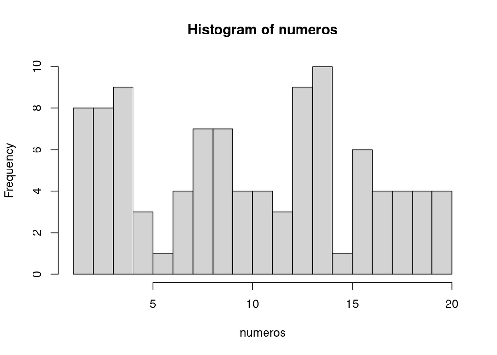

```r
# El argumento breaks nos permite dividir en histograma en las partes que queramos
hist(numeros, breaks = 20)
```

Para obtener un resultado con más precisión, podemos obtener la **moda** si generamos una **tabla de frecuencias** con la función `table` y la función `data.frame`, **aquel elemento con mayor frecuencia será la moda**:

```r
tabla.frecuencias <- data.frame(table(numeros))
tabla.frecuencias
```

```
##    numeros Freq
## 1        1    3
## 2        2    5
## 3        3    8
## 4        4    9
## 5        5    3
## 6        6    1
## 7        7    4
## 8        8    7
## 9        9    7
## 10      10    4
## 11      11    4
## 12      12    3
## 13      13    9
## 14      14   10
## 15      15    1
## 16      16    6
## 17      17    4
## 18      18    4
## 19      19    4
## 20      20    4
```

### 5. Ejercicio

Aplica lo que aprendiste, obten la **mediana**, **media** y **moda** de la siguiente muestra de números:

```r
# Con la función seq, creamos una secuencia de 1 a 10 en intervalos de 0.1 en 0.1
secuencia <- seq(1, 10, 0.1)
muestra <- sample(secuencia, 100, TRUE)
muestra
```

```
##   [1]  8.1  2.9  7.2  8.0  8.8  5.3  4.0  5.5  6.4  5.6  2.1  3.8  2.8  9.0  2.1
##  [16]  7.3 10.0  8.9  7.1  6.7  9.4  9.7  5.9  5.9  7.5  8.5  2.7 10.0  7.4  6.4
##  [31]  1.5  8.4  4.9  5.8  5.3  1.6  3.4  6.2  5.8  1.1  6.1  4.1  9.1  4.7  4.3
##  [46]  8.7  2.0  2.0  4.2  6.5  3.0  2.5  2.6  3.9  6.0  6.2  1.5  2.0  5.6  1.6
##  [61]  9.6  5.2  8.5  9.8  5.8  2.1  3.9  1.3  3.3  6.0  7.5  3.4  8.4  1.3  6.1
##  [76]  8.7  8.2  9.6  5.2  4.8  3.3  2.2  4.6  9.5  7.6  7.5  2.6  7.5  6.8  2.8
##  [91]  6.7  3.2  5.9  4.8  6.6  8.8  6.1  8.9  4.7  6.9
```

##### Mediana

```r
# Aquí el cálculo de la mediana
mediana <-median(muestra)
mediana
```

```
## [1] 5.85
```

##### Media

```r
# Aquí el cálculo de la media
media <-mean(muestra)
media
```

```
## [1] 5.613
```

##### Moda

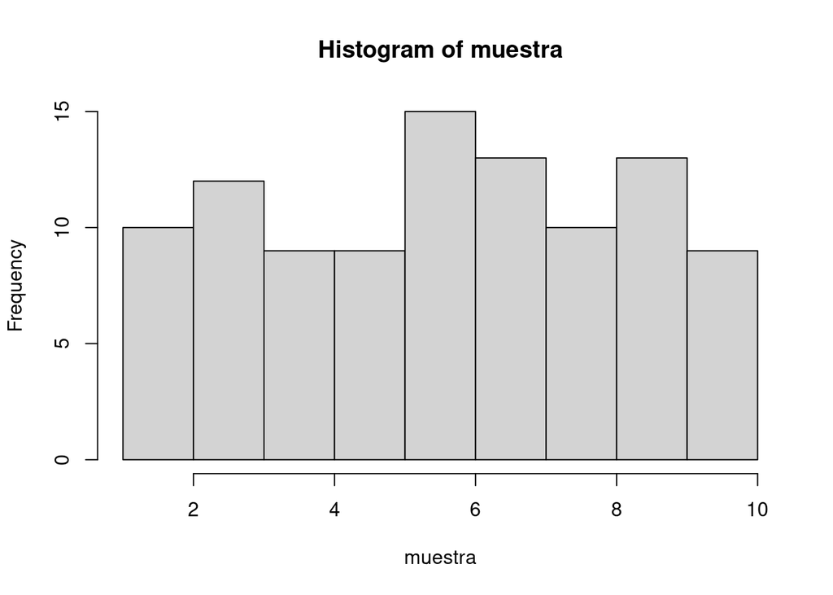

```r
# Aquí el cálculo de la moda
hist(muestra, breaks = 10)
```

```r
#Modo Datatable
tabla.frecuencias <- data.frame(table(muestra))
tabla.frecuencias
```

```
##    muestra Freq
## 1      1.1    1
## 2      1.3    2
## 3      1.5    2
## 4      1.6    2
## 5        2    3
## 6      2.1    3
## 7      2.2    1
## 8      2.5    1
## 9      2.6    2
## 10     2.7    1
## 11     2.8    2
## 12     2.9    1
## 13       3    1
## 14     3.2    1
```

[output cut: 49 more lines]

💻[Código disponible en RStudio Cloud](https://rstudio.cloud/project/3671022)💻